# Session 2

```r
library(tidyverse)
```

## Wir benötigen im Dataframe books nicht die Spalten mit den URLs und bereinigen den Datensatz von Büchern, die angeblich in Jahr 0 oder weniger veröffentlicht wurden und auch von Büchern, bei denen die User ein Veröffentlichungsjahr nach 2020 angegeben haben. Außerdem muss die Spalte ISBN bereinigt werden. Wir haben keinen Business Experten, aber beim googlen kam heraus, dass ISBN Nummern nach 2007 13-stellig sind und davor 10-stellig. Wenn man sich den Datensatz anguckt, gibt es keine 13-stelligen ISBNs in dem Datensatz. Die alten ISBNs haben oft ein X am Ende. Daher nutzen wir grepl, um die Spalte ISBN von ISBNs zu reinigen, die nicht von Anfang bis Ende aus Ziffern von 0-9 oder ein X oder x bestehen.

```r
(books <- BX_Books %>%
  select(ISBN, `Book-Title`, `Book-Author`, `Year-Of-Publication`, `Publisher`) %>%
  filter(`Year-Of-Publication` > 0, `Year-Of-Publication` <= 2020, grepl("^[0-9Xx]+$", ISBN, )))
```

| ISBN | Book-Title | Book-Author | Year-Of-Publication | Publisher |
| --- | --- | --- | --- | --- |
| 0195153448 | Classical Mythology | Mark P. O. Morford | 2002 | Oxford University Press |
| 0002005018 | Clara Callan | Richard Bruce Wright | 2001 | HarperFlamingo Canada |
| 0060973129 | Decision in Normandy | Carlo D'Este | 1991 | HarperPerennial |
| 0374157065 | Flu: The Story of the Great Influenza Pandemic of 1918 and the Search for the Virus That Caused It | Gina Bari Kolata | 1999 | Farrar Straus Giroux |
| 0393045218 | The Mummies of Urumchi | E. J. W. Barber | 1999 | W. W. Norton &amp; Company |
| 0399135782 | The Kitchen God's Wife | Amy Tan | 1991 | Putnam Pub Group |
| 0425176428 | What If?: The World's Foremost Military Historians Imagine What Might Have Been | Robert Cowley | 2000 | Berkley Publishing Group |
| 0671870432 | PLEADING GUILTY | Scott Turow | 1993 | Audioworks |
| 0679425608 | Under the Black Flag: The Romance and the Reality of Life Among the Pirates | David Cordingly | 1996 | Random House |
| 074322678X | Where You'll Find Me: And Other Stories | Ann Beattie | 2002 | Scribner |

[output cut: 990 more lines]

## Wir fügen die Dataframes mit den Ratings und books durch einen inner_join zusammen, um die ISBNs aus beiden Dataframes zu erhalten, die 10 Stellen haben und nur aus Ziffern bestehen und eventuell ein X am Ende beinhalten.

```r
(ratings <- BX_Book_Ratings %>%
  inner_join(books))
```

| User-ID | ISBN | Book-Rating | Book-Title | Book-Author | Year-Of-Publication | Publisher |
| --- | --- | --- | --- | --- | --- | --- |
| 276725 | 034545104X | 0 | Flesh Tones: A Novel | M. J. Rose | 2002 | Ballantine Books |
| 276726 | 0155061224 | 5 | Rites of Passage | Judith Rae | 2001 | Heinle |
| 276727 | 0446520802 | 0 | The Notebook | Nicholas Sparks | 1996 | Warner Books |
| 276729 | 052165615X | 3 | Help!: Level 1 | Philip Prowse | 1999 | Cambridge University Press |
| 276729 | 0521795028 | 6 | The Amsterdam Connection : Level 4 (Cambridge English Readers) | Sue Leather | 2001 | Cambridge University Press |
| 276733 | 2080674722 | 0 | Les Particules Elementaires | Michel Houellebecq | 1998 | Flammarion |
| 276744 | 038550120X | 7 | A Painted House | JOHN GRISHAM | 2001 | Doubleday |
| 276746 | 0425115801 | 0 | Lightning | Dean R. Koontz | 1996 | Berkley Publishing Group |
| 276746 | 0449006522 | 0 | Manhattan Hunt Club | JOHN SAUL | 2002 | Ballantine Books |
| 276746 | 0553561618 | 0 | Dark Paradise | TAMI HOAG | 1994 | Bantam |

[output cut: 990 more lines]

## Wir schauen uns an, wie viele Ratings jeder User abgegeben hat, indem wir nach der user-ID gruppieren und dann zeigen wir in der Spalte n, wie viele Ratings der User abgegeben hat in absteigender Reihenfolge. Im Vergleich zu seinem Notebook sind es dieselben User-IDs ganz oben, aber da ich die ISBNs gereinigt habe, sind die Werte in Spalte n weniger.

```r
(ratings_per_user <- ratings %>%
  group_by(`User-ID`) %>%
  summarize(n = n()) %>%
  arrange(desc(n)))
```

| User-ID | n |
| --- | --- |
| 11676 | 10916 |
| 198711 | 6357 |
| 153662 | 5789 |
| 98391 | 5779 |
| 35859 | 5615 |
| 212898 | 4269 |
| 278418 | 3959 |
| 76352 | 3310 |
| 110973 | 2949 |
| 235105 | 2921 |

[output cut: 990 more lines]

## BX_Users und ratings per User über ein left_Join zusammefügen und die User mit dem Wert 0 in Spalte n (also kein Rating abgegeben) rausfiltern - offenbar habe ich durch die Bereinigung der ISBNs auch schon die Users mit keiner Bewertung aussortiert. Es bleiben 90.676 Zeilen.

```r
(users <- BX_Users %>%
  left_join(ratings_per_user) %>%
  filter(n > 0))
```

| User-ID | Location | Age | n |
| --- | --- | --- | --- |
| 2 | stockton, california, usa | 18 | 1 |
| 8 | timmins, ontario, canada | NA | 17 |
| 9 | germantown, tennessee, usa | NA | 3 |
| 10 | albacete, wisconsin, spain | 26 | 1 |
| 12 | fort bragg, california, usa | NA | 1 |
| 14 | mediapolis, iowa, usa | NA | 4 |
| 16 | albuquerque, new mexico, usa | NA | 2 |
| 17 | chesapeake, virginia, usa | NA | 7 |
| 19 | weston, , | 14 | 1 |
| 20 | langhorne, pennsylvania, usa | 19 | 1 |

[output cut: 990 more lines]

## Wenn wir uns die Spalte “Age” näher anschauen, entscheide ich jetzt aus praktikablen Gründen, dass die Einträge mit “NA” für meine Zwecke unnütz sind, ich möchte ordentlich bereinigte Daten. Außerdem filter ich auch die Altersangaben über 100 raus und die Altersangaben mit 0. Ich denke, dass die User hier falsche Angaben gemacht haben. Ich lasse das Alter 1 drin - kann ja sein, dass die Kinder die Pixibücher schon bewerten :D Auch in der Spalte “Location” finde ich, ist das Land für uns am sinnvollsten zu nutzen. Daher eröffnen wir eine neue Spalte nur mit dem Land.

```r
(users <- users %>%
  filter(!is.na(Age), `Age` <= 100, `Age` != 0) %>%
  mutate(country = str_remove(Location,".*,")) %>%
  filter(country != ""))
```

| User-ID | Location | Age | n | country |
| --- | --- | --- | --- | --- |
| 2 | stockton, california, usa | 18 | 1 | usa |
| 10 | albacete, wisconsin, spain | 26 | 1 | spain |
| 20 | langhorne, pennsylvania, usa | 19 | 1 | usa |
| 36 | montreal, quebec, canada | 24 | 1 | canada |
| 42 | appleton, wisconsin, usa | 17 | 1 | usa |
| 44 | black mountain, north carolina, usa | 51 | 5 | usa |
| 51 | renton, washington, usa | 34 | 1 | usa |
| 56 | cheyenne, wyoming, usa | 24 | 3 | usa |
| 64 | lyon, rhone, france | 32 | 1 | france |
| 67 | framingham, massachusetts, usa | 43 | 4 | usa |

[output cut: 990 more lines]

## Die Größe des Dataframes hat sich mit der Bereinigung der Daten um die Altersangaben von 0 nicht verkleinert, anscheinend war das schon vorher bereinigt. Verstehe nicht wieso… Wo wir das Land rausgeschnitten haben, würde es mich interessieren, wie viele User es pro Land gibt. In den USA, Kanada und Deutschland scheint es die meisten Bücherwürmer mit einer Meinung zu geben.

##Wenn man einmal nach Land absteigend ordnet, ist zu sehen, dass einige Users ihre Länder nicht korrekt angegeben haben oder gar nicht. Einer lebt im Land “universe” - schön

```r
(users %>%
  group_by(country) %>%
  summarize(n = n()) %>%
  arrange(desc(`country`)))
```

| country | n |
| --- | --- |
| " | 1 |
| zimbabwe | 2 |
| zambia | 1 |
| yugoslavia | 3 |
| ysa | 1 |
| x | 1 |
| wales | 3 |
| vietnam | 1 |
| venezuela | 8 |
| uzbekistan | 2 |

[output cut: 195 more lines]

##Im Dataframe users einmal die Einträge in Spalte “country” um falsche Ausdrücke bereinigen.

```r
(users <- users %>%
  mutate(country = str_extract(country, "\\w+")))
```

| User-ID | Location | Age | n | country |
| --- | --- | --- | --- | --- |
| 2 | stockton, california, usa | 18 | 1 | usa |
| 10 | albacete, wisconsin, spain | 26 | 1 | spain |
| 20 | langhorne, pennsylvania, usa | 19 | 1 | usa |
| 36 | montreal, quebec, canada | 24 | 1 | canada |
| 42 | appleton, wisconsin, usa | 17 | 1 | usa |
| 44 | black mountain, north carolina, usa | 51 | 5 | usa |
| 51 | renton, washington, usa | 34 | 1 | usa |
| 56 | cheyenne, wyoming, usa | 24 | 3 | usa |
| 64 | lyon, rhone, france | 32 | 1 | france |
| 67 | framingham, massachusetts, usa | 43 | 4 | usa |

[output cut: 990 more lines]

## Durch str_extract suchen wir den ersten match raus, daher wird United Kingdom zu United.Nochmal den bereinigten Dataframe anschauen - weniger Zeilen, aber zB mehr Einträge bei USA und Germany.

```r
(users %>%
  group_by(country) %>%
  summarize(n = n()) %>%
  arrange(desc(`n`)))
```

| country | n |
| --- | --- |
| usa | 31666 |
| canada | 4500 |
| germany | 3324 |
| united | 2790 |
| spain | 2161 |
| australia | 1900 |
| france | 875 |
| italy | 607 |
| new | 461 |
| switzerland | 418 |

[output cut: 166 more lines]

## Wir schauen uns die Verteilung an, wie oft ein Rating pro User abgegeben wurde. 10916 Ratings pro User wurden nur einmal abgegeben. 1 Rating pro User wurde 50390 Mail abgegeben. Der User mit den pber 10.000 Votes sticht deutlich hervor. Der hat anscheinend viel Zeit oder macht das beruflich :)

```r
(ratings.distribution <- ratings %>%
  group_by(`User-ID`) %>%
  summarize(n = n()) %>%
   arrange(desc(n)) %>%
  group_by(n) %>%
  summarize(m = n()) )
```

| n | m |
| --- | --- |
| 1 | 50390 |
| 2 | 10623 |
| 3 | 5731 |
| 4 | 3778 |
| 5 | 2671 |
| 6 | 2037 |
| 7 | 1568 |
| 8 | 1222 |
| 9 | 1051 |
| 10 | 888 |

[output cut: 647 more lines]

## Wir schauen uns in einem Histogram veranschaulicht an und cutten die Häufigkeit von Rating pro User bei 100, sonst würde das Histogram zerspringen.

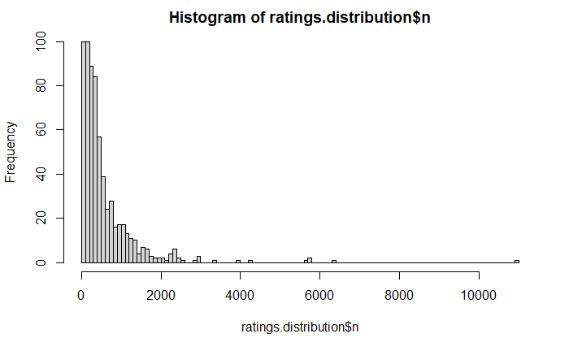

```r
hist(ratings.distribution$n, breaks=100)
```

#Hausuafgabe 1

## Kopiert aus meinem Notebook Session 1 und an kleinen Stellen angepasst.

## Die Besten Bcüher: Ich gehe direkt zur der Fragestellung über, ob die Anzahl der Bewertungen auch eine Rolle spielt, daher der Median und nicht der Mean.

```r
(ratings %>%
  filter(`Book-Rating` > 0) %>%
  group_by(`Book-Title`) %>%
  summarise (dieBestenBuecher = median(`Book-Rating`), wieviele = n()) %>%
  arrange(desc(dieBestenBuecher), desc(wieviele)) %>%
  filter(wieviele > 10))
```

| Book-Title | dieBestenBuecher | wieviele |
| --- | --- | --- |
| Harry Potter and the Prisoner of Azkaban (Book 3) | 10.0 | 277 |
| Harry Potter and the Goblet of Fire (Book 4) | 10.0 | 247 |
| Harry Potter and the Order of the Phoenix (Book 5) | 10.0 | 211 |
| The Fellowship of the Ring (The Lord of the Rings, Part 1) | 10.0 | 205 |
| Harry Potter and the Sorcerer's Stone (Book 1) | 10.0 | 176 |
| The Two Towers (The Lord of the Rings, Part 2) | 10.0 | 136 |
| The Return of the King (The Lord of the Rings, Part 3) | 10.0 | 103 |
| The Little Prince | 10.0 | 90 |
| Charlotte's Web (Trophy Newbery) | 10.0 | 68 |
| The Hobbit | 10.0 | 50 |

[output cut: 990 more lines]

## Die besten Autoren

```r
(ratings %>%
  group_by(`Book-Author`) %>%
  filter(`Book-Rating` > 0) %>%
  summarise(dieBestenBuecher = median(`Book-Rating`), wieviele = n()) %>%
  arrange(desc(dieBestenBuecher), desc(wieviele)) %>%
  filter(wieviele > 10))
```

| Book-Author | dieBestenBuecher | wieviele |
| --- | --- | --- |
| J. K. Rowling | 10.0 | 1746 |
| J.R.R. TOLKIEN | 10.0 | 498 |
| Bill Watterson | 10.0 | 322 |
| Dr. Seuss | 10.0 | 207 |
| Antoine de Saint-Exupéry | 10.0 | 140 |
| Shel Silverstein | 10.0 | 126 |
| Clamp | 10.0 | 109 |
| Bradley Trevor Greive | 10.0 | 73 |
| DR SEUSS | 10.0 | 64 |
| Mary Engelbreit | 10.0 | 53 |

[output cut: 990 more lines]

## Die besten Verlagshäuser.

```r
(ratings %>%
  group_by(`Book-Title`, Publisher) %>%
  filter(`Book-Rating` > 0) %>%
  summarise(dieBestenBuecher = median(`Book-Rating`), wieviele = n()) %>%
  arrange(desc(dieBestenBuecher), desc(wieviele)) %>%
  filter(wieviele > 10))
```

| Book-Title | Publisher | dieBestenBuecher | wieviele |
| --- | --- | --- | --- |
| Harry Potter and the Prisoner of Azkaban (Book 3) | Scholastic | 10.0 | 274 |
| Harry Potter and the Order of the Phoenix (Book 5) | Scholastic | 10.0 | 208 |
| Harry Potter and the Sorcerer's Stone (Book 1) | Scholastic | 10.0 | 176 |
| Harry Potter and the Goblet of Fire (Book 4) | Scholastic | 10.0 | 137 |
| The Fellowship of the Ring (The Lord of the Rings, Part 1) | Del Rey | 10.0 | 131 |
| The Two Towers (The Lord of the Rings, Part 2) | Del Rey | 10.0 | 83 |
| The Return of the King (The Lord of the Rings, Part 3) | Del Rey | 10.0 | 77 |
| The Fellowship of the Ring (The Lord of the Rings, Part 1) | Houghton Mifflin Company | 10.0 | 73 |
| Charlotte's Web (Trophy Newbery) | HarperTrophy | 10.0 | 68 |
| The Little Prince | Harcourt | 10.0 | 54 |

[output cut: 990 more lines]

#Hausaufgabe 2

## Ich nehme den Dataframe ratings, da ich den schon teilweise bereinigt habe. Offenbar sind die Verlage in verschiedenen Schreibformen hinterlegt. Hier müssten für die Verlage, die offensichtlich dieselben sind, die Anzahl der Bücher zusammengerechnet werden.

```r
(amount_books_per_publisher <- ratings %>%
  group_by(`Publisher`) %>%
  summarize(n = n()) %>%
  arrange(desc(`Publisher`)))
```

| Publisher | n |
| --- | --- |
| Zzdap Publishing | 3 |
| Zytglogge Verlag | 2 |
| Zytglogge-Verlag | 3 |
| Zytglogge | 5 |
| Zymurgy Publishing | 3 |
| Zweitauseneins | 1 |
| Zumaya Pubns | 4 |
| Zumaya Publications | 12 |
| Zulma | 8 |
| ZSOLNAY-VERLAG | 1 |

[output cut: 990 more lines]

## Haben ältere Bücher mehr Ratings, weil sie mehr Zeit hatten Ratings zu sammeln?

## Die Frage ist eigentlich schon unlogisch, da es das Internet und damit die Bewertungsplattofrm noch nicht so lange gibt, wie es die meisten “älteren” Bücher gibt. Sie sind also quasi gleich auf wie jüngere Bücher, die ab dem gleichen Zeitpunkt bewertet werden konnten, nämlich ab dem Zeitpunkt, ab dem es die Bewertungsplattform gab. Wenn man sich den neuen Dataframe Ratings_older_books anschaut, sieht man zB, dass 2001, als die erste Verfilmung der Harry PoOtter Bücher (welche hier Top-Bewertungen erhalten haben), erschienen ist und im Juli 1999 das dritte Buch der Reihe.

##Die meisten Bewertungen gibt es für Bücher, die zwischen 1984 und 2004 erschienen sind.

```r
(ratings_older_books <- ratings %>%
   group_by(`Year-Of-Publication`) %>%
   summarize(n = n()) %>%
   arrange(desc(n)))
```

| Year-Of-Publication | n |
| --- | --- |
| 2002 | 91781 |
| 2001 | 79765 |
| 1999 | 75184 |
| 2003 | 72536 |
| 2000 | 72319 |
| 1998 | 64220 |
| 1997 | 59355 |
| 1996 | 58817 |
| 1995 | 54090 |
| 1994 | 46444 |

[output cut: 98 more lines]